# Birds on Rottnest Data Analysis

# Birds on Rottnest Island

Rottnest Island is a unique island off the coast of Perth. It is a popular tourist destination to see Quokkas and go snorkling.

A number of annual surveys are carried out on Rottnest Island and some of that data is included in the dataset used in this notebook.

```r
suppressMessages(library(data.table))
suppressMessages(library(tidyverse))
suppressMessages(library(chron))
suppressMessages(library(patchwork))
#for maps
library(ozmaps)
library(sf)
library(betareg)
abs_ced <- ozmap_data("abs_ced")
#useful for filtering for good surveys
best_survey_types <- c("2ha, 20 minute search", "500m area search", "5km area search")
```

Read in data. In a separate script `extractRottnestData.R` I have extracted just the Rottnest Island observations to a csv. This allows us to quickly load them into this file, something that is particularly convenient when knitting the document to HTML.

```r
rotto_surveys <- fread("../data/rottnestObservations.csv")
rotto_surveys %>% head()
```

| Survey ID | Source | Source Ref | Completed | All Species Recorded | Survey Point ID | Survey Point Name | Latitude | Longitude | Accuracy (m) | Number of Observers | Survey Notes | Start Date | Start Time | Finish Date | Survey Type | Duration (mins) | Program | Water Level | Raisers Edge ID | User Name | Private Survey | Shared Site | KBA.x | Sighting ID | Date Created.x | Time Created.x | Date Entered | Time Entered | Sequential ID | … |
| --- | --- | --- | --- | --- | --- | --- | --- | --- | --- | --- | --- | --- | --- | --- | --- | --- | --- | --- | --- | --- | --- | --- | --- | --- | --- | --- | --- | --- | --- | --- |
| 587514 | Atlas Record Forms | 142568 | Yes | No | 176291 | Lake Baghdad, Rottnest Island | -31.99306 | 115.4972 | 500 | 1 |  | 2001-04-07 | 14:30:00 | 2001-04-07 | Incidental search | NA | General Birdata |  |  | Generic import user | No |  |  | 4227213 | 2004-11-01 | 18:20:29 |  |  | NA | … |
| 589994 | Atlas Record Forms | 145182 | Yes | Yes | 176964 | Salmon Bay, Rottnest Island | -32.02222 | 115.5167 | 500 | 1 |  | 2001-04-06 | 11:00:00 | 2001-04-06 | 500m area search | 40 | General Birdata |  | 1259 | Steve Reynolds | No |  |  | 4275788 | 2004-11-01 | 18:21:34 |  |  | NA | … |
| 589994 | Atlas Record Forms | 145182 | Yes | Yes | 176964 | Salmon Bay, Rottnest Island | -32.02222 | 115.5167 | 500 | 1 |  | 2001-04-06 | 11:00:00 | 2001-04-06 | 500m area search | 40 | General Birdata |  | 1259 | Steve Reynolds | No |  |  | 4275789 | 2004-11-01 | 18:21:34 |  |  | NA | … |
| 589994 | Atlas Record Forms | 145182 | Yes | Yes | 176964 | Salmon Bay, Rottnest Island | -32.02222 | 115.5167 | 500 | 1 |  | 2001-04-06 | 11:00:00 | 2001-04-06 | 500m area search | 40 | General Birdata |  | 1259 | Steve Reynolds | No |  |  | 4275790 | 2004-11-01 | 18:21:34 |  |  | NA | … |
| 589994 | Atlas Record Forms | 145182 | Yes | Yes | 176964 | Salmon Bay, Rottnest Island | -32.02222 | 115.5167 | 500 | 1 |  | 2001-04-06 | 11:00:00 | 2001-04-06 | 500m area search | 40 | General Birdata |  | 1259 | Steve Reynolds | No |  |  | 4275791 | 2004-11-01 | 18:21:34 |  |  | NA | … |
| 589994 | Atlas Record Forms | 145182 | Yes | Yes | 176964 | Salmon Bay, Rottnest Island | -32.02222 | 115.5167 | 500 | 1 |  | 2001-04-06 | 11:00:00 | 2001-04-06 | 500m area search | 40 | General Birdata |  | 1259 | Steve Reynolds | No |  |  | 4275792 | 2004-11-01 | 18:21:34 |  |  | NA | … |

We can group by survey point (this may group multiple surveys) to do a diagnostic plot confirming that our data is actually on Rottnest Island:

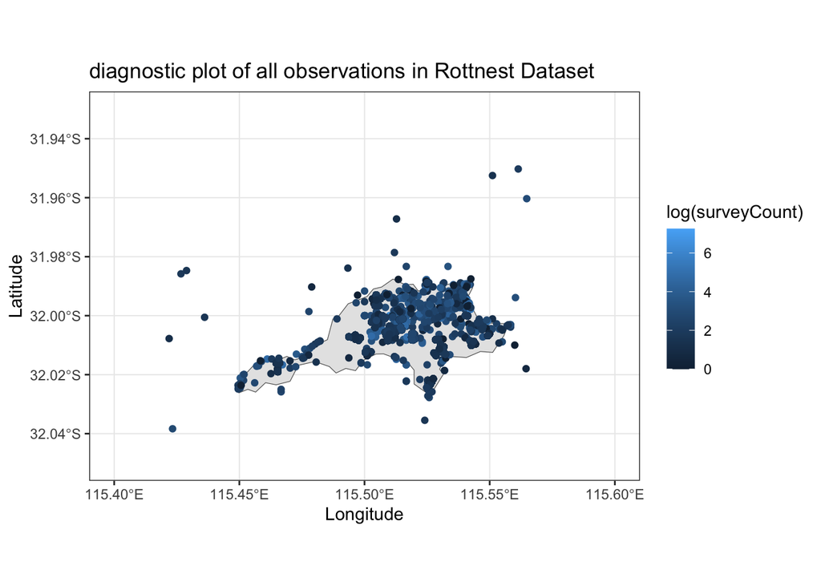

```r
uniqueSurveysByLocation <- rotto_surveys %>%
    group_by(`Survey Point ID`) %>%
    summarise(
        Latitude = first(Latitude),
        Longitude = first(Longitude),
        surveyCount = n()
    )

#plot to check
ggplot(abs_ced) + geom_sf() +
    coord_sf(xlim = c(115.4,115.6), ylim = c(-31.93,-32.05)) +
    geom_point(
        aes(Longitude, Latitude, colour = log(surveyCount)),
        data = uniqueSurveysByLocation
    ) +
    ggtitle("diagnostic plot of all observations in Rottnest Dataset") +
    theme_bw()
```

# data cleaning

We can do some quick data cleaning to remove data where not all species were recorded or the survey is not marked complete:

```r
rottoClean <- rotto_surveys %>%
    filter(Completed == "Yes", `All Species Recorded` == "Yes")
```

# data features

Not all surveys are equal! In this dataset we have several different types of surveys. Including some surveys that are unique to Rottnest Island.

We can see in the `Source` column a hint at what type of survey has been done. We have a number of different “sources” here including eBird (another bird observation platform), old Atlas Records, “pelagic” trips (bird surveys done from boats), a long running project - “Perth Suburban Bird Project”, and individual records from Birdata.

```r
rottoClean$Source %>% unique()
```

```
## [1] "Atlas Record Forms"            "Pelagic"
## [3] "Birdata (2004 - 2016)"         "BirdInfo"
## [5] "Eremaea Birds"                 "eBird (allocated survey type)"
## [7] "Birdata"                       "Perth Suburban Bird Project"
## [9] "BirdLife WA"
```

Within Birdata there are standardised survey types. We can see that our dataset lists these and that different surveys have been done with very different frequencies. By far the most common survey type is the “5 minute point search”.

```r
rottoClean %>% group_by(`Survey Type`) %>%
    count() %>% arrange(desc(n))
```

| Survey Type | n |
| --- | --- |
| 5 minute point search | 10906 |
| 5km area search | 5126 |
| 500m area search | 1945 |
| Shorebird count | 1096 |
| 2ha, 20 minute search | 655 |
| Bird list | 490 |
| 2ha, non-20 minute search | 149 |
| Incidental search | 92 |
| Fixed route search | 86 |

Although not clearly labelled, a subset of this dataset is actually a bushbird survey. We can label it as such and see how it impacts our results.

To find these surveys we can look for the string “Rottnest” within the `Source ref` variable.

Repeating the same survey type table as above, we can see that only 49 of the 10,000 5 minute point surveys were not part of the bushbird surveys. This means we can expect the bush bird surveys to significantly skew the dataset.

```r
#add a variable marking the bushbird surveys
rottoClean <- rottoClean %>%
    mutate(bushBirdSurveys = str_detect(`Source Ref`, "Rottnest"))
#repeat the survey type table using the new variable
rottoClean %>% group_by(`Survey Type`, bushBirdSurveys) %>%
    count() %>% arrange(desc(n))
```

| Survey Type | bushBirdSurveys | n |
| --- | --- | --- |
| 5 minute point search | TRUE | 10857 |
| 5km area search | FALSE | 5126 |
| 500m area search | FALSE | 1945 |
| Shorebird count | FALSE | 1096 |
| 2ha, 20 minute search | FALSE | 655 |
| Bird list | FALSE | 490 |
| 2ha, non-20 minute search | FALSE | 149 |
| Incidental search | FALSE | 92 |
| Fixed route search | FALSE | 86 |
| 5 minute point search | FALSE | 49 |

To protect against bias, any analysis will require focusing on a specific type(s) of survey. Here, we are primarily interested in two high quality groups:

1. the bushbird surveys
2. standardised birdata app surveys

“standardised birdata app surveys” mean those that are one of the following types: “2ha, 20 minute search”, “500m area search”, “5km area search”

We can create dataframes for each of these and then explore them.

```r
#bushbirds
bushbirds <- rottoClean %>%
    filter(bushBirdSurveys)

standardSurveys <- rottoClean %>%
    filter(`Survey Type` %in% best_survey_types)

#adding a variable to our dataframe for this is helpful later
rottoClean <- rottoClean %>%
    #make surveyGroup to use for groupBy
    mutate(
        surveyGroup = case_when(
            bushBirdSurveys ~ "bushBirds",
            `Survey Type` %in% best_survey_types ~ "standardSurveys",
            .default = "other"
        ))
```

# data exploration

We can see that there are 160 unique species recorded in this dataset. 157 of these are present in the standardised surveys while only 45 are present in the bushbird surveys.

```r
rottoClean %>%
    group_by(`Scientific Name`) %>%
    summarise(n()) %>% dim()
```

```
## [1] 160   2
```

```r
bushbirds %>%
    group_by(`Scientific Name`) %>%
    summarise(n()) %>% dim()
```

```
## [1] 45  2
```

```r
standardSurveys %>%
    group_by(`Scientific Name`) %>%
    summarise(n()) %>% dim()
```

```
## [1] 157   2
```

This reflects the locations covered by the bush bird and standardised surveys.

Standardised surveys are done by individuals working by themselves or in small groups. The bush bird surveys are conducted at specific locations designed to capture sightings of bush birds on Rottnest Island.

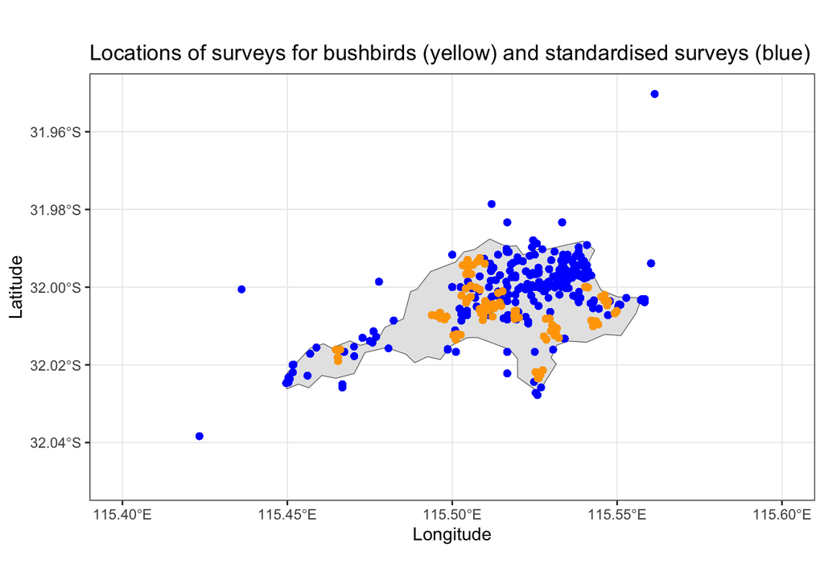

```r
ggplot(abs_ced) + geom_sf() +
    coord_sf(xlim = c(115.4,115.6), ylim = c(-31.95,-32.05)) +
    geom_point(
        aes(Longitude, Latitude),
        data = standardSurveys,
        color = "blue"
    ) +
    geom_point(
        aes(Longitude, Latitude),
        data = bushbirds,
        color = "orange"
    ) +
    ggtitle("Locations of surveys for bushbirds (yellow) and standardised surveys (blue)") +
    theme_bw()
```

What species are seen most often? The table below returns the count of these species on Rottnest Island. We can see that this list is dominated by bush birds thanks to the large number of bush bird surveys. When we exclude this group and look at the standarised surveys and other surveys we see that water birds and waders become dominant.

```r
rotto_species_counts <- rottoClean %>%
    group_by(surveyGroup, `Common Name`, `Scientific Name`) %>%
    summarise(rotto_count=n()) %>% arrange(desc(rotto_count))
rotto_species_counts %>% head()
```

| surveyGroup | Common Name | Scientific Name | rotto_count |
| --- | --- | --- | --- |
| bushBirds | Western Gerygone | Gerygone fusca | 2047 |
| bushBirds | Silvereye | Zosterops lateralis | 1621 |
| bushBirds | Golden Whistler | Pachycephala pectoralis | 1385 |
| bushBirds | Australian Raven | Corvus coronoides | 1226 |
| bushBirds | White-browed Scrubwren | Sericornis frontalis | 1119 |
| bushBirds | Singing Honeyeater | Gavicalis virescens | 887 |

```r
rotto_species_counts %>% filter(surveyGroup == "other") %>% head()
```

| surveyGroup | Common Name | Scientific Name | rotto_count |
| --- | --- | --- | --- |
| other | Silver Gull | Chroicocephalus novaehollandiae | 166 |
| other | Australian Shelduck | Tadorna tadornoides | 127 |
| other | Crested Tern | Thalasseus bergii | 112 |
| other | Red-capped Plover | Charadrius ruficapillus | 94 |
| other | Australian Pied Oystercatcher | Haematopus longirostris | 78 |
| other | Red-necked Stint | Calidris ruficollis | 77 |

```r
rotto_species_counts %>% filter(surveyGroup == "standardSurveys") %>% head()
```

| surveyGroup | Common Name | Scientific Name | rotto_count |
| --- | --- | --- | --- |
| standardSurveys | Silver Gull | Chroicocephalus novaehollandiae | 317 |
| standardSurveys | Welcome Swallow | Hirundo neoxena | 301 |
| standardSurveys | Crested Tern | Thalasseus bergii | 263 |
| standardSurveys | Australian Shelduck | Tadorna tadornoides | 257 |
| standardSurveys | Australian Raven | Corvus coronoides | 256 |
| standardSurveys | Singing Honeyeater | Gavicalis virescens | 228 |

We can see that, for all surveys, there is a median of 4 species observed per survey. Excluding the bush bird surveys, we can see that other surveys and standardised surveys have higher medians.

```r
rottoClean %>% group_by(`Survey ID`) %>%
    summarise(n = n()) %>%
    summarise(
        mean = mean(n),
        median = median(n))
```

| mean | median |
| --- | --- |
| 6.460692 | 4 |

```r
rottoClean %>% group_by(surveyGroup, `Survey ID`) %>%
    summarise(n = n()) %>%
    group_by(surveyGroup) %>%
    summarise(
        mean = mean(n),
        median = median(n))
```

| surveyGroup | mean | median |
| --- | --- | --- |
| bushBirds | 4.262662 | 4 |
| other | 8.074074 | 6 |
| standardSurveys | 19.810256 | 13 |

A density plot of each group of surveys illustrates the difference in species counts that the above statistics were hinting at. Notably, very few standardised surveys saw less than 5 species. This is due to the time spent doing the survey is also standardised at at least 5 minutes.

```r
#create a summarised dataframe of counts by survey ID
uniqueSpeciesRottoLocation <- rottoClean %>%
    group_by(`Survey ID`, surveyGroup) %>%
    summarise(
        n = n(),
        Latitude = first(Latitude),
        Longitude = first(Longitude)
    )
```

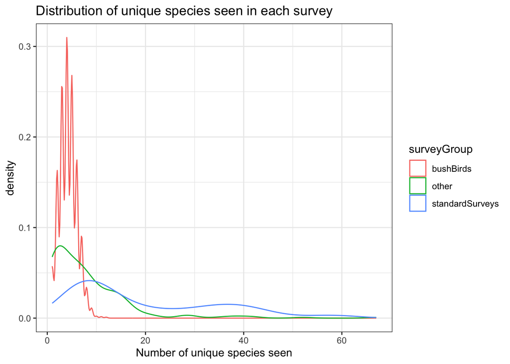

```r
#plot
uniqueSpeciesRottoLocation %>%
    ggplot(aes(n, group = surveyGroup, colour = surveyGroup)) +
    geom_density() +
    xlab("Number of unique species seen") +
    theme_bw() +
    ggtitle("Distribution of unique species seen in each survey")
```

# annual bushbird surveys

Let’s look closer at the bush bird surveys.

Only last 3 years. Not much to go on.

```r
bushbirds <- bushbirds %>%
    mutate(Month = as.numeric(format(`Start Date`, "%m")),
                 Year = as.numeric(format(`Start Date`, "%Y")))
bushbirds$Year %>% unique()
```

```
## [1] 2019 2020 2021
```

We can see that some species were seen very frequently while others were seen much less frequently.

```r
bushbirds %>%
    group_by(`Common Name`) %>%
    count() %>%
    arrange(desc(n)) %>%
    mutate(percent = (n/2547)*100) %>%
    head
```

| Common Name | n | percent |
| --- | --- | --- |
| Western Gerygone | 2047 | 80.36906 |
| Silvereye | 1621 | 63.64350 |
| Golden Whistler | 1385 | 54.37770 |
| Australian Raven | 1226 | 48.13506 |
| White-browed Scrubwren | 1119 | 43.93404 |
| Singing Honeyeater | 887 | 34.82528 |

## Observers vs species count?

No significant difference, but worth nothing that Year seems to correlate with number of observers?

```r
sep_obsv_vs_spec_counts <- bushbirds %>% group_by(`Survey ID`, `Number of Observers`, Year) %>%
    summarise(species_count = n())
```

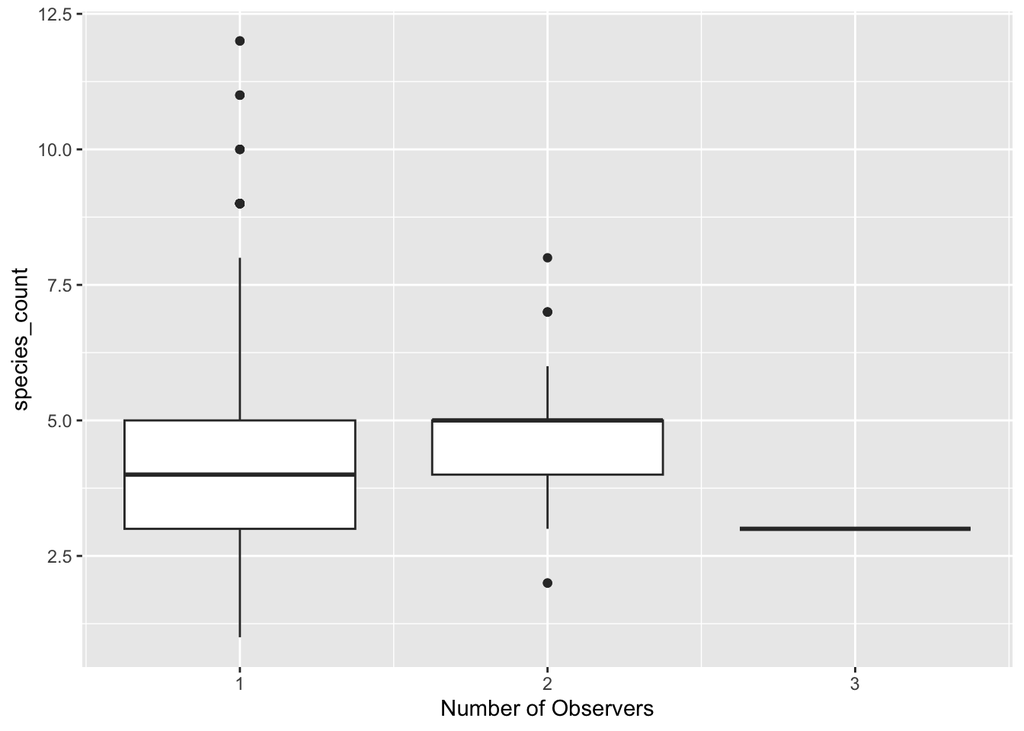

```r
sep_obsv_vs_spec_counts %>%
    ggplot(aes(`Number of Observers`, species_count, group=`Number of Observers`)) + geom_boxplot()
```

```r
model.sep_obsv_vs_spec_counts <- glm(species_count ~ `Number of Observers`*Year, data = sep_obsv_vs_spec_counts)
summary(model.sep_obsv_vs_spec_counts)
```

```
##
## Call:
## glm(formula = species_count ~ `Number of Observers` * Year, data = sep_obsv_vs_spec_counts)
##
## Deviance Residuals:
##     Min       1Q   Median       3Q      Max
## -3.3604  -1.2465  -0.2465   0.8673   7.8673
##
## Coefficients:
##                              Estimate Std. Error t value Pr(>|t|)
## (Intercept)                 1743.0874  1380.7467   1.262    0.207
## `Number of Observers`      -1968.8059  1374.0506  -1.433    0.152
## Year                          -0.8613     0.6838  -1.260    0.208
## `Number of Observers`:Year     0.9752     0.6805   1.433    0.152
##
## (Dispersion parameter for gaussian family taken to be 3.023388)
##
##     Null deviance: 7719.3  on 2546  degrees of freedom
## Residual deviance: 7688.5  on 2543  degrees of freedom
## AIC: 10052
##
## Number of Fisher Scoring iterations: 2
```

Year negatively correlated with number of observers. Looks like surveys in 2021 well all a single person. Which is consistent with what I observed when participating in 2022.

```r
model.year.observers <- glm(`Number of Observers` ~ Year, data = sep_obsv_vs_spec_counts)
summary(model.year.observers)
```

```
##
## Call:
## glm(formula = `Number of Observers` ~ Year, data = sep_obsv_vs_spec_counts)
##
## Deviance Residuals:
##      Min        1Q    Median        3Q       Max
## -0.03619  -0.03619  -0.01705   0.00210   1.96381
##
## Coefficients:
##              Estimate Std. Error t value Pr(>|t|)
## (Intercept) 39.689349   6.194572   6.407 1.76e-10 ***
## Year        -0.019145   0.003066  -6.243 5.00e-10 ***
## ---
## Signif. codes:  0 '***' 0.001 '**' 0.01 '*' 0.05 '.' 0.1 ' ' 1
##
## (Dispersion parameter for gaussian family taken to be 0.0168086)
##
##     Null deviance: 43.433  on 2546  degrees of freedom
## Residual deviance: 42.778  on 2545  degrees of freedom
## AIC: -3174.6
##
## Number of Fisher Scoring iterations: 2
```

```r
sep_obsv_vs_spec_counts %>%
    group_by(Year, `Number of Observers`) %>%
    summarise(n=n())
```

| Year | Number of Observers | n |
| --- | --- | --- |
| 2019 | 1 | 741 |
| 2019 | 2 | 24 |
| 2019 | 3 | 3 |
| 2020 | 1 | 720 |
| 2020 | 2 | 8 |
| 2021 | 1 | 1051 |

# species observed

As seen above, 45 species were observed. The most frequently observed were Western Gerygones and Silvereyes.

```r
bushbirds %>% group_by(`Common Name`) %>%
    summarise(n=n()) %>% arrange(desc(n)) %>%
    head(5)
```

| Common Name | n |
| --- | --- |
| Western Gerygone | 2047 |
| Silvereye | 1621 |
| Golden Whistler | 1385 |
| Australian Raven | 1226 |
| White-browed Scrubwren | 1119 |

## by year?

Species diversity at each survey site? Seems to differ based on location.

```r
sep_count_by_survey_point <- bushbirds %>%
    group_by(`Survey Point Name`,`Common Name`) %>%
    summarise(n = n(),Lon=mean(Longitude), Lat=mean(Latitude)) %>%
    group_by(Lon, Lat, `Survey Point Name`) %>%
    summarise(species_count = n())
```

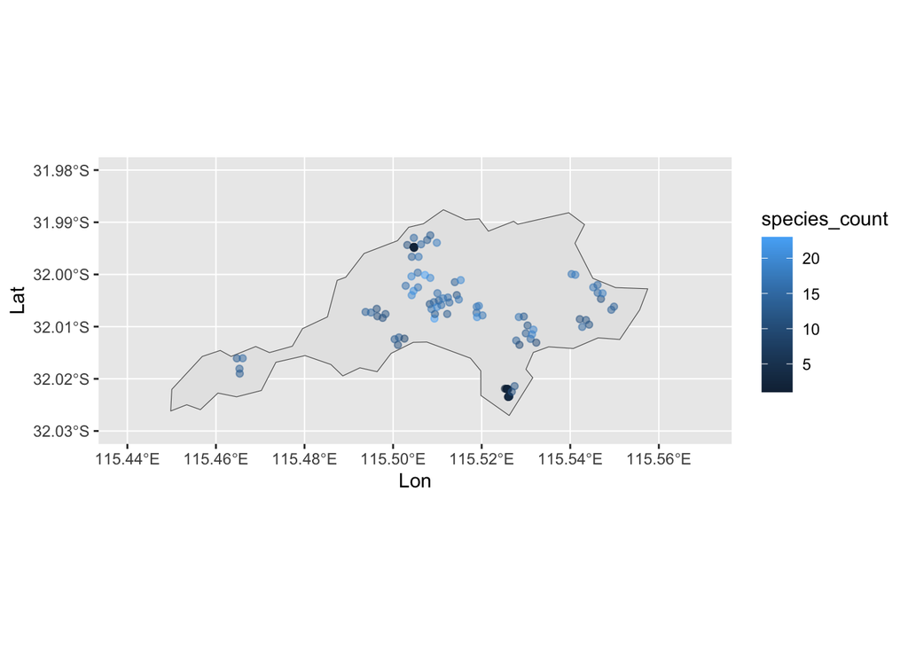

```r
ggplot(abs_ced) + geom_sf() +
    coord_sf(xlim = c(115.44,115.57), ylim = c(-31.98,-32.03)) +
    geom_point(
        aes(Lon, Lat, colour = species_count),
        data = sep_count_by_survey_point,
        alpha = 0.5
    )
```

## survey point names

I was previously curious about whether the numbering system for survey point identifiers was following a pattern. I later learned that the original sites did follow a pattern but that this pattern was not followed as points were added later.

Split out the number from “R” and plot by colour on map to try and observe a pattern. As can be seen, there is a distinct pattern to the points where those close together geographically tend to have similar numbers.

```r
sep_count_by_survey_point_name <- bushbirds %>%
    #make survey point name as number
    mutate(
        Survey_point_number = str_remove(`Survey Point Name`,"R") %>%
               as.numeric()
    ) %>%
    group_by(Survey_point_number,`Common Name`) %>%
    summarise(n = n(),Lon=mean(Longitude), Lat=mean(Latitude)) %>%
    group_by(Lon, Lat, Survey_point_number) %>%
    summarise(species_count = n())
```

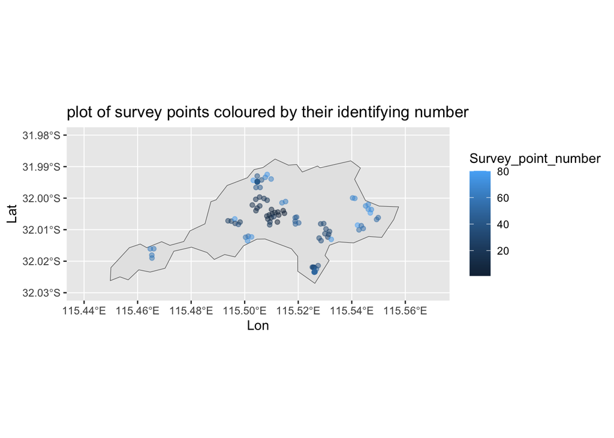

```r
ggplot(abs_ced) + geom_sf() +
    coord_sf(xlim = c(115.44,115.57), ylim = c(-31.98,-32.03)) +
    geom_point(
        aes(Lon, Lat, colour = Survey_point_number),
        data = sep_count_by_survey_point_name,
        alpha = 0.5
    ) + ggtitle("plot of survey points coloured by their identifying number")
```

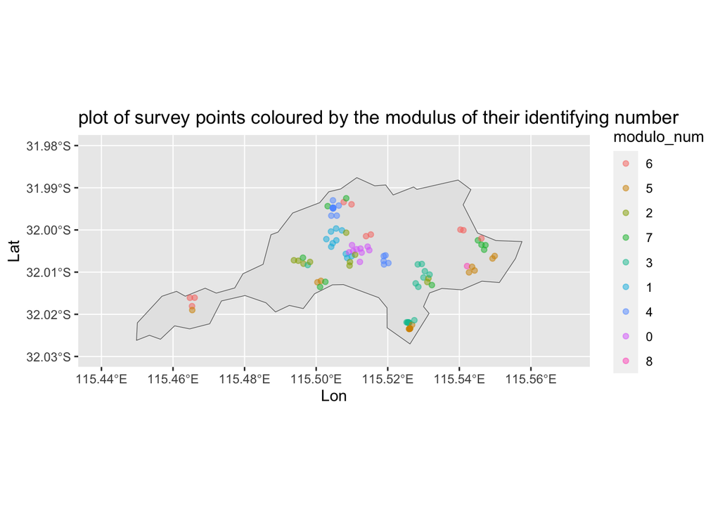

```r
ggplot(abs_ced) + geom_sf() +
    coord_sf(xlim = c(115.44,115.57), ylim = c(-31.98,-32.03)) +
    geom_point(
        aes(Lon, Lat, colour = modulo_num),
        data = sep_count_by_survey_point_name %>%
            mutate(modulo_num = Survey_point_number %/% 10 %>% as.factor()),
        alpha = 0.5
    ) +
    ggtitle("plot of survey points coloured by the modulus of their identifying number")
```

Has every survey point done in all (3) years? No, a few points have only be done once. These points are likely new points added in the past year.

```r
bushbirds %>%
    group_by(Year, `Survey Point Name`) %>%
    summarise(species_count=n()) %>%
    group_by(`Survey Point Name`) %>%
    summarise(n=n()) %>%
    filter(n!=3)
```

| Survey Point Name | n |
| --- | --- |
| R73 | 1 |
| R74 | 1 |
| R75 | 1 |
| R76 | 1 |
| R77 | 1 |
| R78 | 1 |
| R79 | 1 |
| R80 | 1 |

Below, is a series of plots showing the locations that Red capped robins were seen over the 3 years of the surveys. While we can see that robins were seen at most locations in all three years, some sites only observed them in one year or another.

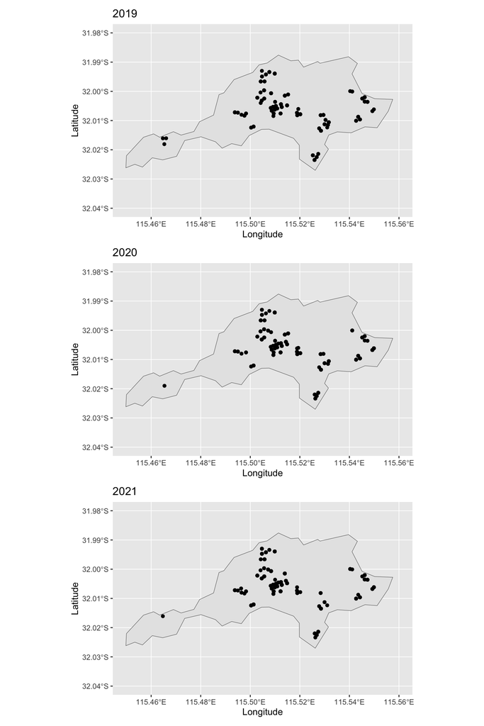

```r
RCP_2019 <- ggplot(abs_ced) + geom_sf() +
    coord_sf(xlim = c(115.45,115.56), ylim = c(-31.98,-32.04)) +
    geom_point(
        aes(Longitude, Latitude),
        data = bushbirds %>% filter(
            `Common Name` == "Red-capped Robin",
            Year == 2019
        )
    ) + ggtitle("2019")
RCP_2020 <- ggplot(abs_ced) + geom_sf() +
    coord_sf(xlim = c(115.45,115.56), ylim = c(-31.98,-32.04)) +
    geom_point(
        aes(Longitude, Latitude),
        data = bushbirds %>% filter(
            `Common Name` == "Red-capped Robin",
            Year == 2020
        )
    ) + ggtitle("2020")
RCP_2021 <- ggplot(abs_ced) + geom_sf() +
    coord_sf(xlim = c(115.45,115.56), ylim = c(-31.98,-32.04)) +
    geom_point(
        aes(Longitude, Latitude),
        data = bushbirds %>% filter(
            `Common Name` == "Red-capped Robin",
            Year == 2021
        )
    ) + ggtitle("2021")

RCP_2019/RCP_2020/RCP_2021
```

# Distance from observer for each species

Part of the 5 minute survey involves recording the distance to the observed bird.

This allows us to draw distributions of how far away a bird is typically observed.

```r
bushbirds_distance <- bushbirds %>%
    separate(`Sighting Notes`, sep = ",", into = as.character(1:8)) %>%
    pivot_longer(
        as.character(1:7),
        values_to = "Distance and count"
    ) %>%
    drop_na("Distance and count") %>%
    filter(`Distance and count`!= "") %>%
    separate(
        "Distance and count",
        sep = "=",
        into = c("Distance", "count")
    ) %>%
    mutate(Distance = str_trim(Distance)) %>%
    mutate(
        ordinal_distance = case_when(
          Distance == "0-5m" ~ 1,
          Distance == "5-10m" ~ 2,
          Distance == "10-15m" ~ 3,
          Distance == "15-20m" ~ 4,
          Distance == "20-30m" ~ 5,
          Distance == "30-40m" ~ 6,
          Distance == "40-50m" ~ 7,
          Distance == ">50m" ~ 8
        )
    ) %>%
    drop_na(ordinal_distance)
bushbirds_distance %>%
    select(c("Source Ref","Survey Point Name",`Common Name`,"Distance", ordinal_distance, "count"))
```

| Source Ref | Survey Point Name | Common Name | Distance | ordinal_distance | count |
| --- | --- | --- | --- | --- | --- |
| Rottnest2019S1 | R64 | Fan-tailed Cuckoo | >50m | 8 | 1 |
| Rottnest2019S1 | R64 | Welcome Swallow | 15-20m | 4 | 1 |
| Rottnest2019S1 | R64 | Red-capped Robin | 0-5m | 1 | 1 |
| Rottnest2019S1 | R64 | Western Gerygone | 20-30m | 5 | 1 |
| Rottnest2019S1 | R64 | Silvereye | 15-20m | 4 | 1 |
| Rottnest2019S2 | R63 | Sacred Kingfisher | >50m | 8 | 1 |
| Rottnest2019S2 | R63 | Silvereye | >50m | 8 | 1 |
| Rottnest2019S2 | R63 | Australian Raven | >50m | 8 | 1 |
| Rottnest2019S3 | R01 | Sacred Kingfisher | >50m | 8 | 1 |
| Rottnest2019S3 | R01 | Golden Whistler | >50m | 8 | 1 |

[output cut: 9990 more lines]

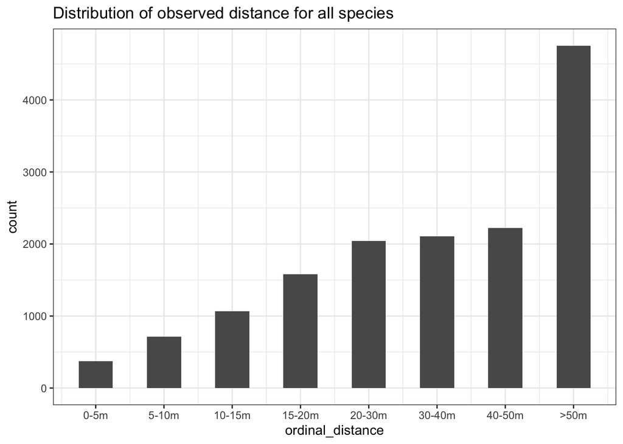

```r
distance_labels = c("0-5m","5-10m","10-15m","15-20m","20-30m","30-40m","40-50m",">50m")
species_of_interest = c(
    "Red-capped Robin","Silvereye","Australian Magpie","Western Gerygone",
    "Australian Raven","Sacred Kingfisher"
)
#all species
bushbirds_distance %>%
    ggplot(aes(ordinal_distance)) +
    geom_histogram(binwidth = 0.5) +
    ggtitle("Distribution of observed distance for all species") +
    scale_x_continuous(breaks = 1:8, labels = distance_labels) +
    theme_bw()
```

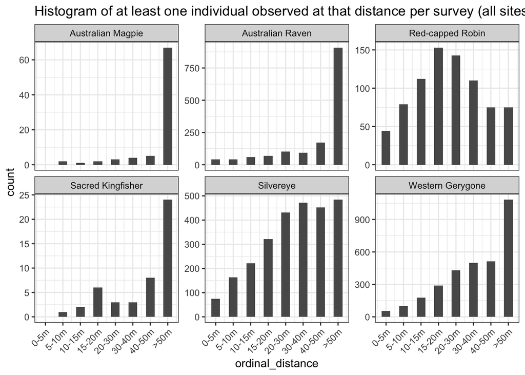

```r
#specific species
bushbirds_distance %>%
    filter(
        `Common Name` %in% species_of_interest
    ) %>%
    ggplot(aes(ordinal_distance)) +
    geom_histogram(binwidth = 0.5) +
    facet_wrap(vars(`Common Name`), scales = "free_y") +
    ggtitle("Histogram of at least one individual observed at that distance per survey (all sites, all years)") +
    scale_x_continuous(breaks = 1:8, labels = distance_labels) +
    theme_bw() +
    theme(axis.text.x=element_text(angle=45,hjust=1))
```

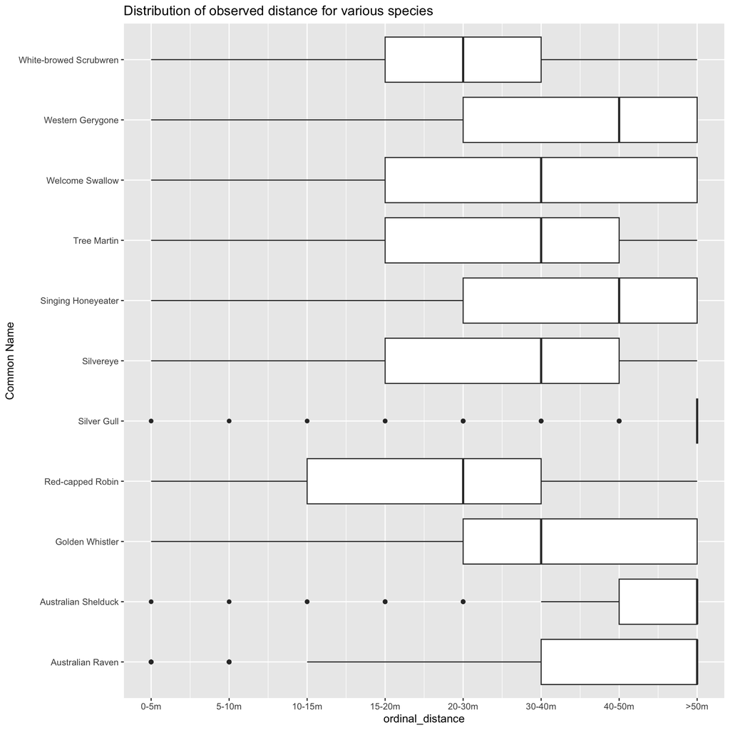

```r
over_100_bushbirds <- bushbirds_distance %>%
    group_by(`Common Name`) %>% count() %>%
    filter(n > 100) %>%
    pull(`Common Name`)
bushbirds_distance %>%
    filter(`Common Name` %in% over_100_bushbirds) %>%
    ggplot(aes(ordinal_distance, `Common Name`, group = `Common Name`)) +
    geom_boxplot() +
    scale_x_continuous(breaks = 1:8, labels = distance_labels) +
    ggtitle("Distribution of observed distance for various species")
```